# Manuscript figures

Reproducible figure file for the CPC manuscript

```r
library(dplyr)
library(forcats)
library(ggalluvial)
library(ggdist)
library(ggplot2)
library(ggrepel)
library(knitr)
library(mgcv)
library(patchwork)
library(purrr)
library(ranger)
library(readr)
library(readxl)
library(stringr)
library(tibble)
library(tidyr)
library(viridis)
library(viridisLite)

find_repo_root <- function(start = getwd()) {
  current <- normalizePath(start, winslash = "/", mustWork = TRUE)
  repeat {
    if (file.exists(file.path(current, "CPCs_predict_CommunityStability.Rproj"))) {
      return(current)
    }
    parent <- dirname(current)
    if (identical(parent, current)) {
      stop("Could not locate the CPCs_predict_CommunityStability repository root.")
    }
    current <- parent
  }
}

repo_root <- find_repo_root()
empirical_root <- file.path(repo_root, "new_empirical_study")
publication_root <- file.path(repo_root, "publication_experiments", "data")
literature_file_path <- file.path(repo_root, "literature_review", "data", "literature_file.xls")

theme_manuscript <- function(base_size = 12) {
  theme_bw(base_size = base_size) +
    theme(
      panel.grid.minor = element_blank(),
      panel.grid.major = element_line(colour = "grey92"),
      strip.text = element_text(face = "bold", colour = "black"),
      legend.position = "bottom",
      plot.tag = element_text(face = "bold")
    )
}

theme_clean <- function(base_size = 20) {
  theme_minimal(base_size = base_size) +
    theme(
      panel.grid.minor = element_blank(),
      strip.text = element_text(face = "bold", colour = "black"),
      legend.position = "bottom",
      plot.tag = element_text(face = "bold")
    )
}

format_p <- function(p) {
  ifelse(p < 0.001, "< 0.001", sprintf("%.3f", p))
}
```

# Figure 1 - empirical version

Although this figure is NOT included in the manuscript, it shows how one could potentially recreate a very similar figure from empirical data (in this case, from out ciliate microcosm experiment). Code to reproduce the figure shown in the manuscript is right below.

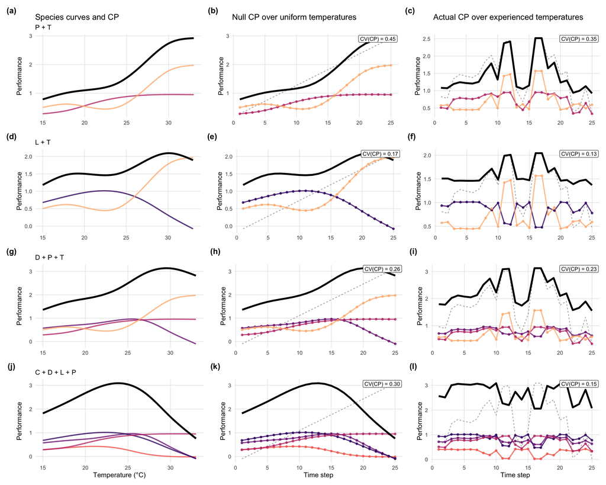

```r
figure1_communities <- c("PT", "LT", "DPT", "CDLP")
figure1_actual_temperatures <- tibble(
  time = seq_along(T_norm2),
  temperature = T_norm2
)
figure1_null_temperatures <- tibble(
  time = seq_along(T_norm2),
  temperature = seq(min(TPCs$temperature), max(TPCs$temperature), length.out = length(T_norm2))
)

species_colours <- setNames(
  viridisLite::magma(length(species_list), begin = 0.20, end = 0.85),
  species_list
)

community_label <- function(composition_name) {
  paste(strsplit(composition_name, "")[[1]], collapse = " + ")
}

predict_species_performance <- function(composition_name, temperature_df) {
  community_species <- strsplit(composition_name, "")[[1]]

  crossing(
    temperature_df,
    species = community_species
  ) |>
    mutate(
      performance = map2_dbl(
        species,
        temperature,
        ~ as.numeric(predict(
          tpc_gams_design[[.x]],
          newdata = tibble(temperature = .y)
        ))
      )
    )
}

community_cp_timeseries <- function(composition_name, temperature_df) {
  predict_species_performance(composition_name, temperature_df) |>
    group_by(time) |>
    mutate(community_performance = sum(performance)) |>
    ungroup()
}

scale_temperature_trace <- function(temperature_df, y_values) {
  y_range <- range(y_values, na.rm = TRUE, finite = TRUE)
  temp_range <- range(temperature_df$temperature, na.rm = TRUE, finite = TRUE)

  if (!all(is.finite(y_range)) || diff(y_range) == 0 ||
      !all(is.finite(temp_range)) || diff(temp_range) == 0) {
    return(mutate(temperature_df, temperature_scaled = mean(y_range)))
  }

  temperature_df |>
    mutate(
      temperature_scaled = y_range[1] +
        (temperature - temp_range[1]) / diff(temp_range) * diff(y_range)
    )
}

curve_column <- function(composition_name, show_title = FALSE, show_x = FALSE) {
  community_species <- strsplit(composition_name, "")[[1]]

  species_curves <- TPCs |>
    filter(species %in% community_species)

  cp_curve <- species_curves |>
    group_by(temperature) |>
    summarise(community_performance = sum(predicted), .groups = "drop")

  p <- ggplot() +
    geom_line(
      data = species_curves,
      aes(x = temperature, y = predicted, colour = species),
      linewidth = 1.05,
      alpha = 0.78
    ) +
    geom_line(
      data = cp_curve,
      aes(x = temperature, y = community_performance),
      linewidth = 1.55,
      colour = "black"
    ) +
    scale_colour_manual(
      values = species_colours,
      limits = species_list,
      breaks = species_list,
      drop = FALSE
    ) +
    theme_clean(12) +
    labs(
      title = if (show_title) "Species curves and CP" else NULL,
      subtitle = community_label(composition_name),
      x = "Temperature (°C)",
      y = "Performance",
      colour = "Species"
    )

  if (!show_x) {
    p <- p + theme(axis.title.x = element_blank())
  }

  p
}

timeseries_column <- function(composition_name, temperature_df, title, show_x = FALSE) {
  plot_data <- community_cp_timeseries(composition_name, temperature_df)
  cp_data <- plot_data |>
    distinct(time, community_performance)

  cp_cv <- sd(cp_data$community_performance) / mean(cp_data$community_performance)
  temperature_trace <- scale_temperature_trace(
    temperature_df,
    c(plot_data$performance, cp_data$community_performance)
  )

  p <- ggplot() +
    geom_line(
      data = temperature_trace,
      aes(x = time, y = temperature_scaled),
      inherit.aes = FALSE,
      colour = "grey35",
      linewidth = 0.7,
      linetype = "22",
      alpha = 0.45
    ) +
    geom_line(
      data = plot_data,
      aes(x = time, y = performance, colour = species, group = species),
      linewidth = 0.95,
      alpha = 0.78
    ) +
    geom_point(
      data = plot_data,
      aes(x = time, y = performance, colour = species),
      size = 1.4,
      alpha = 0.78
    ) +
    geom_line(
      data = cp_data,
      aes(x = time, y = community_performance),
      linewidth = 1.55,
      colour = "black"
    ) +
    annotate(
      "label",
      x = Inf,
      y = Inf,
      hjust = 1.03,
      vjust = 1.12,
      label = paste0("CV(CP) = ", sprintf("%.2f", cp_cv)),
      label.size = 0.18,
      size = 3.4
    ) +
    scale_colour_manual(
      values = species_colours,
      limits = species_list,
      breaks = species_list,
      drop = FALSE
    ) +
    theme_clean(12) +
    labs(
      title = title,
      x = "Time step",
      y = "Performance",
      colour = "Species"
    )

  if (!show_x) {
    p <- p + theme(axis.title.x = element_blank())
  }

  p
}

figure1_rows <- imap(figure1_communities, function(composition_name, row_index) {
  show_title <- row_index == 1
  show_x <- row_index == length(figure1_communities)

  curve_column(composition_name, show_title = show_title, show_x = show_x) |
    timeseries_column(
      composition_name,
      figure1_null_temperatures,
      title = if (show_title) "Null CP over uniform temperatures" else NULL,
      show_x = show_x
    ) |
    timeseries_column(
      composition_name,
      figure1_actual_temperatures,
      title = if (show_title) "Actual CP over experienced temperatures" else NULL,
      show_x = show_x
    )
})

wrap_plots(figure1_rows, ncol = 1) +
  plot_layout(guides = "collect") +
  plot_annotation(tag_levels = "a", tag_prefix = "(", tag_suffix = ")") &
  theme(legend.position = "none")
```

Figure 1, empirical version. Conceptual construction of community performance (CP) variability using the empirical ciliate thermal-performance curves. The first column shows species-level thermal performance curves and the summed CP curve for four example communities. The second column evaluates the same species curves over a uniform temperature sequence to produce null CP time series and their CV. The third column evaluates the same curves over one realised experimental temperature sequence to produce actual CP time series and their CV. Thin coloured lines are species-level performance, thick black lines are summed community performance, and dashed grey lines in the time-series panels show the temperature sequence rescaled to the plotting height.

## Figure 1 - Main Text

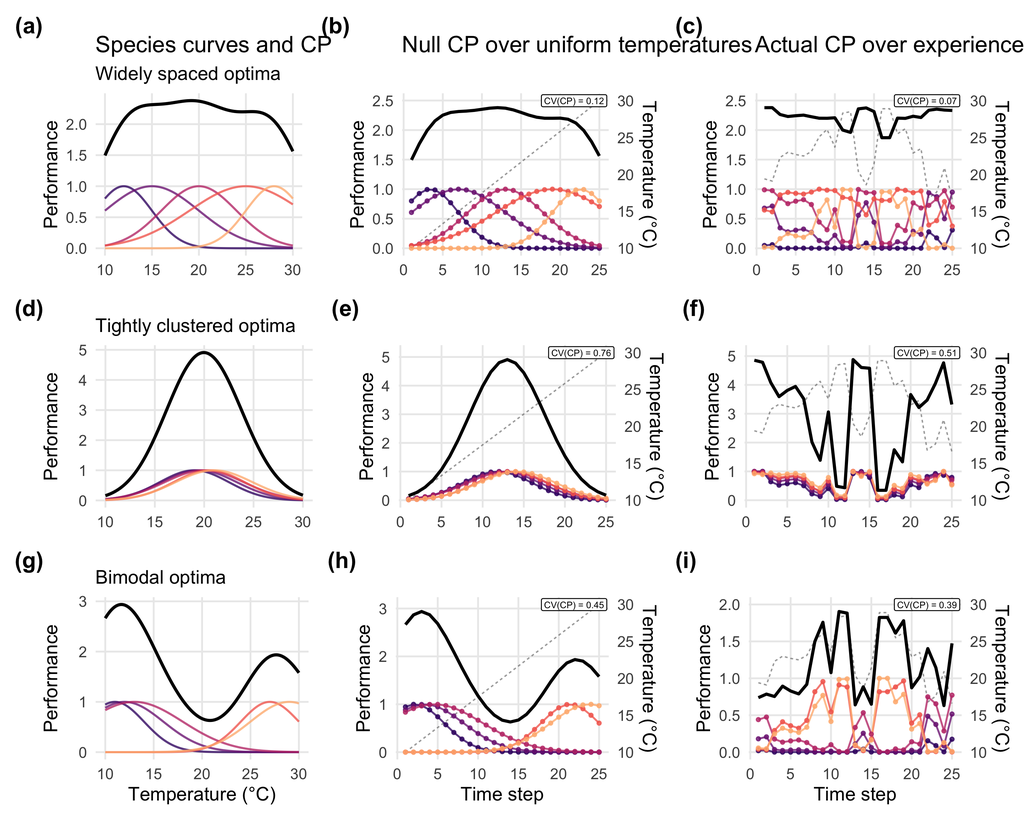

```r
concept_species_colours <- setNames(
  viridisLite::magma(5, begin = 0.20, end = 0.85),
  paste0("sp", 1:5)
)

concept_temperature_grid <- seq(10, 30, length.out = 250)

concept_null_temperatures <- tibble(
  time = seq_len(25),
  temperature = seq(10, 30, length.out = 25)
)

concept_actual_temperatures <- tibble(
  time = seq_along(T_norm2),
  temperature = T_norm2
)

concept_species_sets <- list(
  "Widely spaced optima" = tibble(
    species = paste0("sp", 1:5),
    Topt = c(12, 15, 20, 25, 28),
    width = c(3, 5, 4, 6, 3)
  ),
  "Tightly clustered optima" = tibble(
    species = paste0("sp", 1:5),
    Topt = c(19, 19.5, 20, 20.5, 21),
    width = c(3.5, 3.8, 4, 3.6, 3.9)
  ),
  "Cool-skewed optima" = tibble(
    species = paste0("sp", 1:5),
    Topt = c(11, 12, 13, 14, 15),
    width = c(3, 4, 5, 3, 4)
  ),
  "Bimodal optima" = tibble(
    species = paste0("sp", 1:5),
    Topt = c(11, 12, 13, 27, 29),
    width = c(3, 4, 5, 3, 4)
  )
)

concept_performance <- function(temperature, optimum, width) {
  exp(-0.5 * ((temperature - optimum) / width)^2)
}

concept_species_performance <- function(species_df, temperature_df) {
  crossing(temperature_df, species_df) |>
    mutate(
      performance = concept_performance(temperature, Topt, width)
    )
}

concept_cp_timeseries <- function(species_df, temperature_df) {
  concept_species_performance(species_df, temperature_df) |>
    group_by(time) |>
    mutate(community_performance = sum(performance)) |>
    ungroup()
}

concept_viability_timeseries <- function(species_df, temperature_df,
                                         threshold = 0.35) {
  concept_species_performance(species_df, temperature_df) |>
    mutate(viable = as.numeric(performance >= threshold)) |>
    group_by(time) |>
    mutate(community_viability = mean(viable)) |>
    ungroup()
}

concept_curve_column <- function(species_df, community_label,
                                 show_title = FALSE, show_x = FALSE) {
  curve_temperatures <- tibble(
    time = seq_along(concept_temperature_grid),
    temperature = concept_temperature_grid
  )

  species_curves <- concept_species_performance(species_df, curve_temperatures)

  cp_curve <- species_curves |>
    group_by(temperature) |>
    summarise(community_performance = sum(performance), .groups = "drop")

  p <- ggplot() +
    geom_line(
      data = species_curves,
      aes(x = temperature, y = performance, colour = species),
      linewidth = 1.05,
      alpha = 0.78
    ) +
    geom_line(
      data = cp_curve,
      aes(x = temperature, y = community_performance),
      linewidth = 1.55,
      colour = "black"
    ) +
    scale_colour_manual(values = concept_species_colours, drop = FALSE) +
    theme_clean(20) +
    labs(
      title = if (show_title) "Species curves and CP" else NULL,
      subtitle = community_label,
      x = "Temperature (°C)",
      y = "Performance",
      colour = "Species"
    )

  if (!show_x) {
    p <- p + theme(axis.title.x = element_blank())
  }

  p
}

concept_timeseries_column <- function(species_df, temperature_df,
                                      title, show_x = FALSE) {
  plot_data <- concept_cp_timeseries(species_df, temperature_df)

  cp_data <- plot_data |>
    distinct(time, community_performance)

  cp_cv <- sd(cp_data$community_performance) / mean(cp_data$community_performance)

  # Use a common temperature range in every panel
  temperature_limits <- c(10, 30)

  # Primary y-axis is used for both species performance and summed CP
  y_limits <- c(
    0,
    max(c(plot_data$performance, cp_data$community_performance)) * 1.05
  )

  # Rescale temperature onto the primary y-axis for plotting
  temperature_trace <- temperature_df |>
    mutate(
      temperature_scaled =
        (temperature - temperature_limits[1]) /
        diff(temperature_limits) *
        diff(y_limits) +
        y_limits[1]
    )

  # Exact inverse transformation for the secondary temperature axis
  temperature_inverse <- function(y) {
    (y - y_limits[1]) /
      diff(y_limits) *
      diff(temperature_limits) +
      temperature_limits[1]
  }

  p <- ggplot() +
    geom_line(
      data = temperature_trace,
      aes(x = time, y = temperature_scaled),
      colour = "grey35",
      linewidth = 0.7,
      linetype = "22",
      alpha = 0.55
    ) +
    geom_line(
      data = plot_data,
      aes(x = time, y = performance, colour = species, group = species),
      linewidth = 0.95,
      alpha = 0.78
    ) +
    geom_point(
      data = plot_data,
      aes(x = time, y = performance, colour = species),
      size = 1.4,
      alpha = 0.78
    ) +
    geom_line(
      data = cp_data,
      aes(x = time, y = community_performance),
      linewidth = 1.55,
      colour = "black"
    ) +
    annotate(
      "label",
      x = Inf,
      y = Inf,
      hjust = 1.03,
      vjust = 1.12,
      label = paste0("CV(CP) = ", sprintf("%.2f", cp_cv)),
      label.size = 0.18,
      size = 3.4
    ) +
    scale_colour_manual(values = concept_species_colours, drop = FALSE) +
    scale_y_continuous(
      limits = y_limits,
      name = "Performance",
      sec.axis = sec_axis(
        trans = ~ temperature_inverse(.),
        name = "Temperature (°C)",
        breaks = seq(10, 30, by = 5)
      )
    ) +
    theme_clean(20) +
    labs(
      title = title,
      x = "Time step",
      colour = "Species"
    )

  if (!show_x) {
    p <- p + theme(axis.title.x = element_blank())
  }

  p
}

# Remove this one if you do not want to show it
concept_species_sets <- concept_species_sets[
  names(concept_species_sets) != "Cool-skewed optima"
]

concept_figure_rows <- imap(
  concept_species_sets,
  function(species_df, community_label) {
    row_index <- match(community_label, names(concept_species_sets))
    show_title <- row_index == 1
    show_x <- row_index == length(concept_species_sets)

    concept_curve_column(
      species_df,
      community_label,
      show_title = show_title,
      show_x = show_x
    ) |
      concept_timeseries_column(
        species_df,
        concept_null_temperatures,
        title = if (show_title) "Null CP over uniform temperatures" else NULL,
        show_x = show_x
      ) |
      concept_timeseries_column(
        species_df,
        concept_actual_temperatures,
        title = if (show_title) "Actual CP over experienced temperatures" else NULL,
        show_x = show_x
      )
  }
)

concept_figure <- wrap_plots(concept_figure_rows, ncol = 1) +
  plot_layout(guides = "collect") +
  plot_annotation(
    tag_levels = "a",
    tag_prefix = "(",
    tag_suffix = ")"
  ) &
  theme(legend.position = "none")

concept_figure
```

Figure 1, conceptual-community version. This alternative uses 3 idealised communities with widely spaced, tightly clustered, or bimodal species optima. The layout is the same as in the empirical version: species-level performance and summed CP curves are shown in the first column, null-uniform CP time series and CVs in the second column, and actual-environment CP time series and CVs in the third column. Dashed grey lines in the time-series panels show the temperature sequence rescaled to the plotting height.

## Supplementary Figure 1.1

This figure is similar to previous one (Fig.1 in the main text), but it also shows the viability curves.

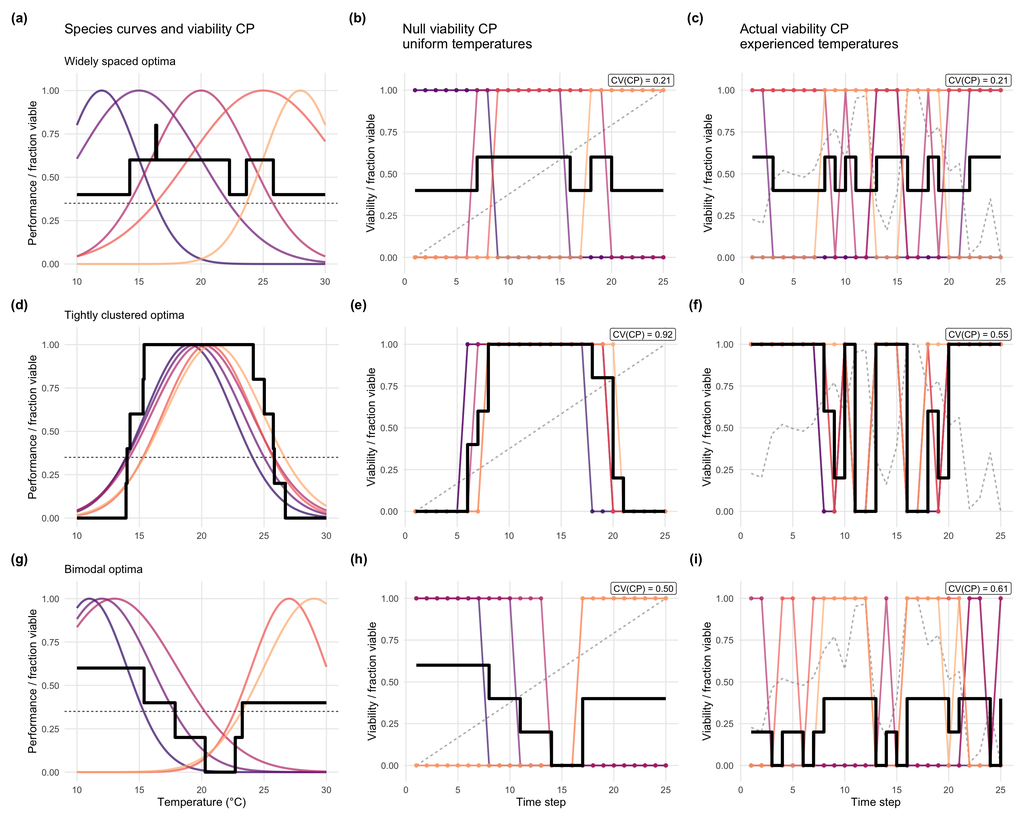

```r
viability_threshold <- 0.35

concept_viability_curve_column <- function(species_df, community_label, show_title = FALSE, show_x = FALSE) {
  curve_temperatures <- tibble(
    time = seq_along(concept_temperature_grid),
    temperature = concept_temperature_grid
  )

  species_curves <- concept_species_performance(species_df, curve_temperatures)

  viability_curve <- species_curves |>
    mutate(viable = as.numeric(performance >= viability_threshold)) |>
    group_by(temperature) |>
    summarise(community_viability = mean(viable), .groups = "drop")

  p <- ggplot() +
    geom_line(
      data = species_curves,
      aes(x = temperature, y = performance, colour = species),
      linewidth = 1.05,
      alpha = 0.70
    ) +
    geom_hline(
      yintercept = viability_threshold,
      colour = "grey35",
      linewidth = 0.55,
      linetype = "22"
    ) +
    geom_step(
      data = viability_curve,
      aes(x = temperature, y = community_viability),
      linewidth = 1.55,
      colour = "black"
    ) +
    scale_colour_manual(values = concept_species_colours, drop = FALSE) +
    coord_cartesian(ylim = c(0, 1.05)) +
    theme_clean(12) +
    labs(
      title = if (show_title) "Species curves and viability CP" else NULL,
      subtitle = community_label,
      x = "Temperature (°C)",
      y = "Performance / fraction viable",
      colour = "Species"
    )

  if (!show_x) {
    p <- p + theme(axis.title.x = element_blank())
  }

  p
}

concept_viability_timeseries_column <- function(species_df, temperature_df, title, show_x = FALSE) {
  plot_data <- concept_viability_timeseries(
    species_df,
    temperature_df,
    threshold = viability_threshold
  )

  viability_data <- plot_data |>
    distinct(time, community_viability)

  viability_cv <- sd(viability_data$community_viability) /
    mean(viability_data$community_viability)

  temperature_trace <- scale_temperature_trace(
    temperature_df,
    c(plot_data$viable, viability_data$community_viability)
  )

  p <- ggplot() +
    geom_line(
      data = temperature_trace,
      aes(x = time, y = temperature_scaled),
      inherit.aes = FALSE,
      colour = "grey35",
      linewidth = 0.7,
      linetype = "22",
      alpha = 0.45
    ) +
    geom_line(
      data = plot_data,
      aes(x = time, y = viable, colour = species, group = species),
      linewidth = 0.85,
      alpha = 0.65
    ) +
    geom_point(
      data = plot_data,
      aes(x = time, y = viable, colour = species),
      size = 1.4,
      alpha = 0.70
    ) +
    geom_step(
      data = viability_data,
      aes(x = time, y = community_viability),
      linewidth = 1.55,
      colour = "black"
    ) +
    annotate(
      "label",
      x = Inf,
      y = Inf,
      hjust = 1.03,
      vjust = 1.12,
      label = paste0("CV(CP) = ", sprintf("%.2f", viability_cv)),
      label.size = 0.18,
      size = 3.4
    ) +
    scale_colour_manual(values = concept_species_colours, drop = FALSE) +
    coord_cartesian(ylim = c(-0.04, 1.05)) +
    theme_clean(12) +
    labs(
      title = title,
      x = "Time step",
      y = "Viability / fraction viable",
      colour = "Species"
    )

  if (!show_x) {
    p <- p + theme(axis.title.x = element_blank())
  }

  p
}

viability_figure_rows <- imap(concept_species_sets, function(species_df, community_label) {
  row_index <- match(community_label, names(concept_species_sets))
  show_title <- row_index == 1
  show_x <- row_index == length(concept_species_sets)

  concept_viability_curve_column(
    species_df,
    community_label,
    show_title = show_title,
    show_x = show_x
  ) |
    concept_viability_timeseries_column(
      species_df,
      concept_null_temperatures,
      title = if (show_title) "Null viability CP\nuniform temperatures" else NULL,
      show_x = show_x
    ) |
    concept_viability_timeseries_column(
      species_df,
      concept_actual_temperatures,
      title = if (show_title) "Actual viability CP\nexperienced temperatures" else NULL,
      show_x = show_x
    )
})

wrap_plots(viability_figure_rows, ncol = 1) +
  plot_layout(guides = "collect") +
  plot_annotation(tag_levels = "a", tag_prefix = "(", tag_suffix = ")") &
  theme(legend.position = "none")
```

Supplementary Figure 1.1. Conceptual construction of viability CP. Species performance curves are first transformed into binary viability using the dashed threshold. The community viability CP is the fraction of species above that threshold at each temperature or time step. Dashed grey traces in the time-series panels show the temperature sequence rescaled to the panel height; black curves show community-level viability CP.

# Figure 2

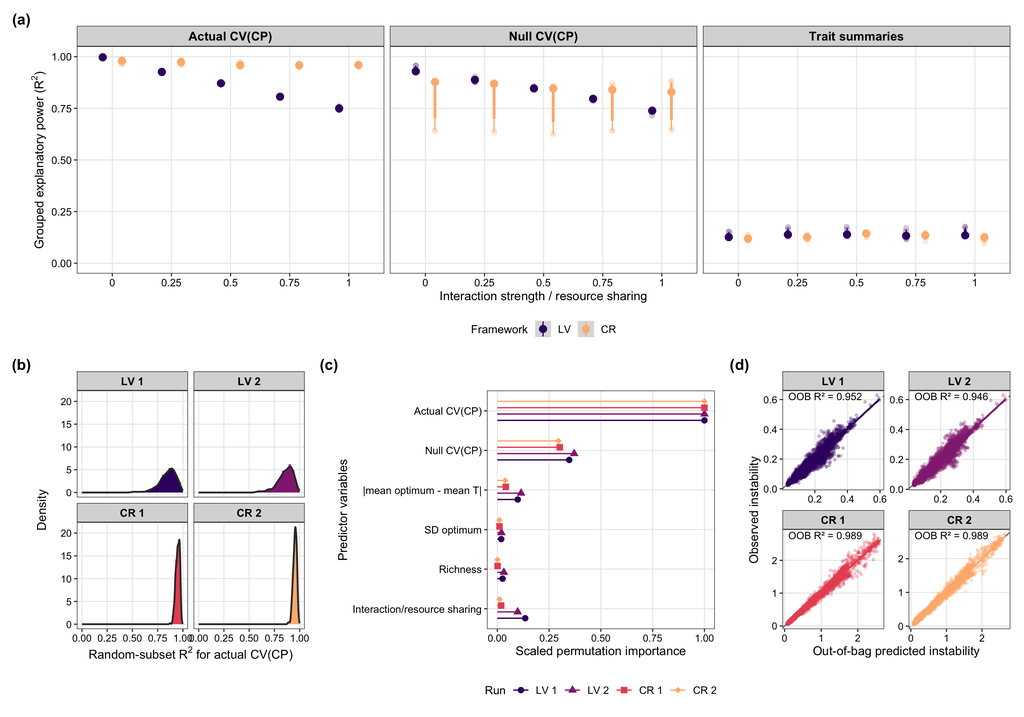

```r
importance_offsets <- tibble(
  experiment_label = factor(
    format_experiment_label(selected_experiments),
    levels = format_experiment_label(selected_experiments)
  ),
  importance_offset = c(-0.24, -0.08, 0.08, 0.24)
)

importance_data <- rf_importance |>
  filter(is.finite(scaled_importance)) |>
  left_join(importance_offsets, by = "experiment_label") |>
  mutate(
    variable_label = factor(variable_label, levels = rev(unname(rf_variable_labels))),
    variable_y = as.numeric(variable_label) + importance_offset
  )

experiment_levels <- unique(c(
  as.character(random_subset_data$experiment_label),
  as.character(importance_data$experiment_label),
  as.character(rf_prediction_data$experiment_label)
))

experiment_colours <- setNames(
  magma(n = length(experiment_levels), begin = 0.20, end = 0.85),
  experiment_levels
)

framework_levels <- c("LV", "CR")

framework_colours <- setNames(
  magma(n = length(framework_levels), begin = 0.20, end = 0.85),
  framework_levels
)

random_subset_data <- random_subset_data |>
  mutate(experiment_label = factor(experiment_label, levels = experiment_levels))

importance_data <- importance_data |>
  mutate(experiment_label = factor(experiment_label, levels = experiment_levels))

rf_prediction_data <- rf_prediction_data |>
  mutate(experiment_label = factor(experiment_label, levels = experiment_levels))

common_theme <- theme_manuscript(12) +
  theme(
    plot.tag = element_text(size = 16, face = "bold"),
    axis.title = element_text(size = 13, colour = "black"),
    axis.text = element_text(size = 11, colour = "black"),
    strip.text = element_text(size = 12, face = "bold", colour = "black"),
    legend.title = element_text(size = 12),
    legend.text = element_text(size = 11),
    legend.key.size = grid::unit(0.7, "cm"),
    panel.grid.major.y = element_line(colour = "grey90", linewidth = 0.4),
    panel.grid.minor = element_blank(),
    plot.margin = margin(t = 7, r = 9, b = 7, l = 7)
  )

panel_a <- grouped_r2 |>
  mutate(
    framework_short = factor(
      framework,
      levels = c("Lotka-Volterra", "Consumer-resource"),
      labels = framework_levels
    )
  ) |>
  ggplot(aes(
    x = treatment_plot,
    y = r2,
    colour = framework_short,
    fill = framework_short
  )) +
  stat_halfeye(
    position = position_dodge(width = 0.65),
    adjust = 0.8,
    width = 0.85,
    slab_alpha = 0.40,
    point_interval = median_qi,
    .width = c(0.5, 0.8),
    point_size = 3
  ) +
  geom_point(
    position = position_jitterdodge(dodge.width = 0.65, jitter.width = 0.03),
    alpha = 0.20,
    size = 2.2,
    show.legend = FALSE
  ) +
  facet_wrap(~ predictor, nrow = 1) +
  scale_colour_manual(values = framework_colours, name = "Framework", drop = FALSE) +
  scale_fill_manual(values = framework_colours, drop = FALSE, guide = "none") +
  coord_cartesian(ylim = c(0, 1)) +
  labs(
    x = "Interaction strength / resource sharing",
    y = expression(paste("Grouped explanatory power (", R^2, ")"))
  ) +
  common_theme +
  theme(
    legend.position = "bottom",
    axis.text.x = element_text(size = 11, angle = 0, hjust = 0.5),
    strip.text = element_text(size = 13, face = "bold")
  )

random_subset_panel <- random_subset_data |>
  ggplot(aes(x = r2, fill = experiment_label)) +
  geom_histogram(
    aes(y = after_stat(density)),
    bins = 32,
    colour = "white",
    linewidth = 0.25,
    alpha = 0.75
  ) +
  geom_density(linewidth = 0.9, colour = "grey20") +
  facet_wrap(~ experiment_label, ncol = 2) +
  scale_fill_manual(values = experiment_colours, drop = FALSE, guide = "none") +
  scale_x_continuous(limits = c(0, 1), breaks = seq(0, 1, by = 0.25)) +
  labs(
    x = expression(paste("Random-subset ", R^2, " for actual CV(CP)")),
    y = "Density"
  ) +
  common_theme +
  theme(
    legend.position = "none",
    axis.text.x = element_text(size = 10.5),
    axis.text.y = element_text(size = 10.5),
    strip.text = element_text(size = 11.5, face = "bold")
  )

importance_plot <- importance_data |>
  ggplot(aes(
    y = variable_y,
    x = scaled_importance,
    colour = experiment_label,
    shape = experiment_label
  )) +
  geom_segment(
    aes(x = 0, xend = scaled_importance, yend = variable_y),
    linewidth = 0.65
  ) +
  geom_point(size = 2.8, stroke = 0.6) +
  scale_colour_manual(values = experiment_colours, drop = FALSE, name = "Run") +
  scale_shape_manual(values = c(16, 17, 15, 18), drop = FALSE, name = "Run") +
  scale_y_continuous(
    breaks = seq_along(levels(importance_data$variable_label)),
    labels = levels(importance_data$variable_label)
  ) +
  scale_x_continuous(limits = c(0, 1), breaks = seq(0, 1, by = 0.25)) +
  labs(
    x = "Scaled permutation importance",
    y = "Predictor variables"
  ) +
  common_theme +
  theme(
    legend.position = "bottom",
    axis.text.x = element_text(size = 10.5),
    axis.text.y = element_text(size = 11),
    panel.grid.major.y = element_line(colour = "grey90", linewidth = 0.4)
  )

rf_accuracy_panel <- rf_prediction_data |>
  ggplot(aes(x = predicted, y = observed, colour = experiment_label)) +
  geom_point(alpha = 0.25, size = 1) +
  geom_abline(
    slope = 1,
    intercept = 0,
    linetype = "dashed",
    colour = "grey50",
    linewidth = 0.65
  ) +
  geom_smooth(method = "lm", se = FALSE, linewidth = 0.9) +
  geom_text(
    data = rf_prediction_data |> distinct(experiment_label, oob_label),
    aes(x = -Inf, y = Inf, label = oob_label),
    inherit.aes = FALSE,
    hjust = -0.08,
    vjust = 1.3,
    size = 3.8,
    colour = "black"
  ) +
  facet_wrap(~ experiment_label, ncol = 2, scales = "free") +
  scale_colour_manual(values = experiment_colours, drop = FALSE, guide = "none") +
  labs(
    x = "Out-of-bag predicted instability",
    y = "Observed instability"
  ) +
  common_theme +
  theme(
    legend.position = "none",
    axis.text.x = element_text(size = 10.5),
    axis.text.y = element_text(size = 10.5),
    strip.text = element_text(size = 11.5, face = "bold")
  )

panel_a /
  (random_subset_panel | importance_plot | rf_accuracy_panel) +
  plot_layout(heights = c(1, 1.05), widths = c(1, 1, 1), guides = "keep") +
  plot_annotation(
    tag_levels = "a",
    tag_prefix = "(",
    tag_suffix = ")"
  )
```

# Figure 3

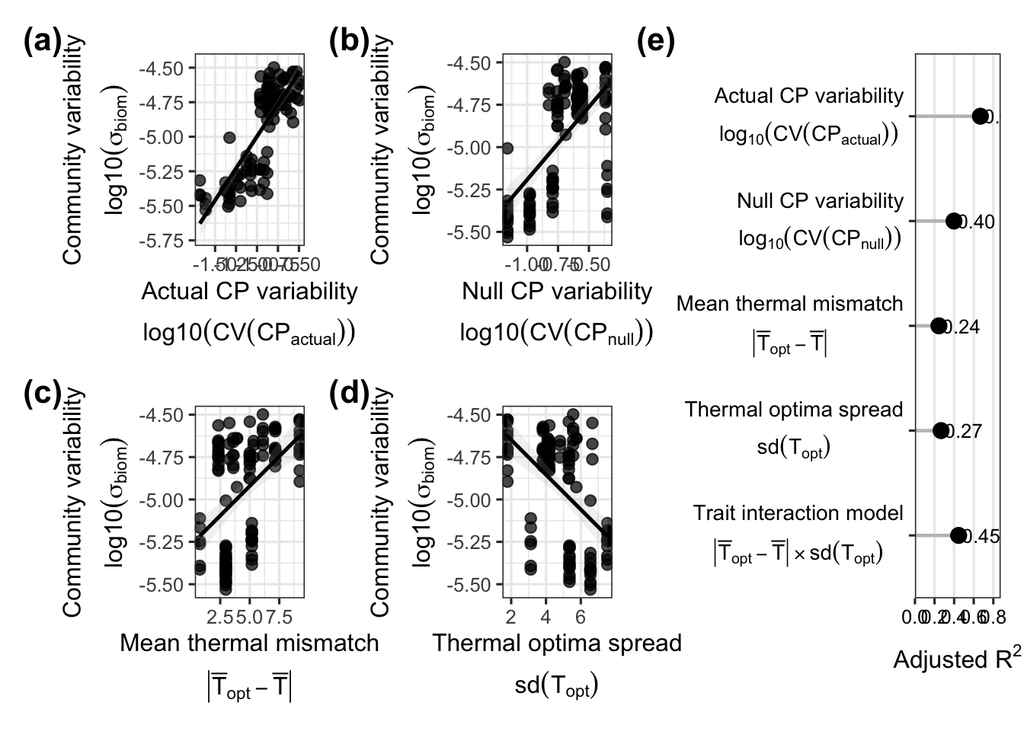

```r
#| label: fig-3
#| fig-height: 8.8
#| fig-width: 18
#| fig-align: center
#| message: false
#| warning: false





plot_actual <- ggplot(data=CPC_CV_df, aes(x=log10(CV_perf_actual), y=log10(sd_biom)))+
  geom_point(alpha=0.72, size=2.2, color="black")+
  geom_smooth(aes(group = 1), method="lm", linewidth=0.9, alpha=0.18, color="black", fill = "grey70")+
  theme_bw(base_size = 12)+
  # annotate(
  #   "text",
  #   x = -Inf, y = Inf,
  #   label = paste0("R^2 == ", round(r2_obs, 2)),
  #   parse = TRUE,
  #   hjust = -0.3, vjust = 1.2,
  #   size = 5
  # )  +
  ylab(expression(atop("Community variability", log10(sigma[biom]))))+
  xlab(expression(atop("Actual CP variability", log10(CV(CP[actual])))))


plot_null <- ggplot(data=CPC_CV_df, aes(x=log10(CV_perf_null), y=log10(sd_biom)))+
  geom_point(alpha=0.72, size=2.2, color="black")+
  geom_smooth(aes(group = 1), method="lm", linewidth=0.9, alpha=0.18, color="black", fill = "grey70")+
  theme_bw(base_size = 12)+
  # annotate(
  #   "text",
  #   x = -Inf, y = Inf,
  #   label = paste0("R^2 == ", round(r2_naive, 2)),
  #   parse = TRUE,
  #   hjust = -0.3, vjust = 1.2,
  #   size = 5
  # )  +
  ylab(expression(atop("Community variability", log10(sigma[biom]))))+
  xlab(expression(atop("Null CP variability", log10(CV(CP[null])))))

plot_mean_T_opt <- ggplot(data=CPC_CV_df, aes(x=T_opt_mean, y=log10(sd_biom)))+
  geom_point(alpha=0.72, size=2.2, color="black") +
  geom_smooth(aes(group = 1), method="lm", linewidth=0.9, alpha=0.18, color="black", fill = "grey70")+
  # annotate(
  #   "text",
  #   x = -Inf, y = Inf,
  #   label = paste0("R^2 == ", round(r2_T_opt_mean, 2)),
  #   parse = TRUE,
  #   hjust = -0.3, vjust = 1.2,
  #   size = 5
  # )  +
  theme_bw(base_size = 12)+
  ylab(expression(atop("Community variability", log10(sigma[biom]))))+
  xlab(expression(atop("Mean thermal mismatch", group("|", bar(T)[opt] - bar(T), "|"))))


plot_sd_T_opt <- ggplot(data=CPC_CV_df, aes(x=sd_T_opt, y=log10(sd_biom)))+
  geom_point(alpha=0.72, size=2.2, color="black")+
  geom_smooth(aes(group = 1), method="lm", linewidth=0.9, alpha=0.18, color="black", fill = "grey70")+
  theme_bw(base_size = 12)+
  # annotate(
  #   "text",
  #   x = -Inf, y = Inf,
  #   label = paste0("R^2 == ", round(r2_T_opt_sd, 2)),
  #   parse = TRUE,
  #   hjust = -0.3, vjust = 1.2,
  #   size = 5
  # )  +
  ylab(expression(atop("Community variability", log10(sigma[biom]))))+
  xlab(expression(atop("Thermal optima spread", sd(T[opt]))))

r2_df <- tibble::tibble(
  variable = c(
    "CV_perf_actual",
    "CV_perf_null",
    "T_opt_mean",
    "sd_T_opt",
    "traits_interaction"
  ),
  r_squared = c(
    summary(m_CPC_obs)$adj.r.squared,
    summary(m_CPC_naive)$adj.r.squared,
    summary(m_T_opt_mean)$adj.r.squared,
    summary(m_T_opt_sd)$adj.r.squared,
    summary(m_traits_interaction)$adj.r.squared
  )
) |>
  dplyr::mutate(
    variable = factor(
      variable,
      levels = c("traits_interaction", "sd_T_opt", "T_opt_mean", "CV_perf_null", "CV_perf_actual")
    )
  )

r2_plot <- ggplot(
  r2_df,
  aes(x = r_squared, y = variable)
) +
  geom_segment(
    aes(
      x = 0,
      xend = r_squared,
      yend = variable
    ),
    linewidth = 0.8,
    colour = "grey75"
  ) +
  geom_point(
    size = 3.2,
    colour = "black"
  ) +
  geom_text(
    aes(label = sprintf("%.2f", r_squared)),
    nudge_x = 0.035,
    hjust = 0,
    size = 3.4
  ) +
  scale_y_discrete(
    labels = c(
      "CV_perf_actual" =
        expression(
          atop(
            "Actual CP variability",
            log[10](CV(CP[actual]))
          )
        ),

      "CV_perf_null" =
        expression(
          atop(
            "Null CP variability",
            log[10](CV(CP[null]))
          )
        ),

      "T_opt_mean" =
        expression(
          atop(
            "Mean thermal mismatch",
            group("|", bar(T)[opt] - bar(T), "|")
          )
        ),

      "sd_T_opt" =
        expression(
          atop(
            "Thermal optima spread",
            sd(T[opt])
          )
        ),

      "traits_interaction" =
        expression(
          atop(
            "Trait interaction model",
            group("|", bar(T)[opt] - bar(T), "|") %*% sd(T[opt])
          )
        )
    )
  ) +
  scale_x_continuous(
    limits = c(0, 0.85),
    breaks = seq(0, 0.8, by = 0.2),
    expand = expansion(mult = c(0, 0.03))
  ) +
  labs(
    x = expression("Adjusted " * R^2),
    y = NULL
  ) +
  theme_bw(base_size = 12) +
  theme(
    panel.grid.major.y = element_blank(),
    panel.grid.minor = element_blank(),
    axis.text.y = element_text(
      size = 10.5,
      colour = "black",
      lineheight = 0.9
    ),
    axis.text.x = element_text(colour = "black"),
    axis.title.x = element_text(
      margin = margin(t = 8)
    )
  )



combined_design <- c(
  area(t = 1, l = 1, b = 1, r = 1),
  area(t = 1, l = 2, b = 1, r = 2),
  area(t = 2, l = 1, b = 2, r = 1),
  area(t = 2, l = 2, b = 2, r = 2),
  area(t = 1, l = 3, b = 2, r = 3)
)

combined_plot <- wrap_plots(
  plot_actual,
  plot_null,
  plot_mean_T_opt,
  plot_sd_T_opt,
  r2_plot,
  design = combined_design,
  widths = c(1, 1, 0.78),
  guides = "collect"
) +
  plot_annotation(tag_levels = "a", tag_prefix = "(", tag_suffix = ")") &
  theme(
    legend.position = "bottom",
    legend.box = "horizontal",
    plot.tag = element_text(size = 16, face = "bold")
  )

combined_plot
```

Figure 3. Empirical predictors of detrended community biomass variability. (a-d) Relationships between community biomass variability and actual $CP$ variability, null $CP$ variability, mean thermal mismatch, and thermal-optimum spread. (e) Adjusted (R^2) values for the corresponding single-predictor and trait-summary models.

# Figure 4

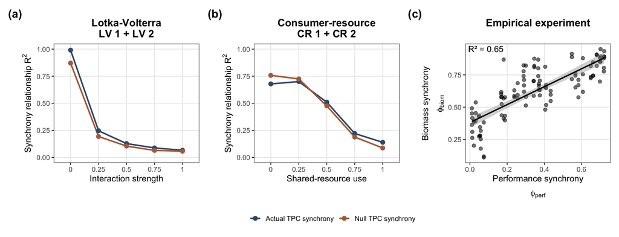

```r
(plot_sync_lv | plot_sync_cr | plot_sync_empirical) +
  plot_layout(guides = "collect") +
  plot_annotation(tag_levels = "a", tag_prefix = "(", tag_suffix = ")") &
  theme(
    legend.position = "bottom",
    plot.tag = element_text(size = 16, face = "bold")
  )
```

Figure 4. Synchrony links between thermal performance and community dynamics. (a-b) Explanatory power of performance synchrony for realised biomass synchrony in the Lotka–Volterra and consumer–resource simulations, calculated separately across interaction-strength or shared-resource-use levels. (c) Relationship between performance synchrony and biomass synchrony in the empirical ciliate communities.